# Risk Factor Analysis

## Outcome Variable

**Outcome Variable:** ever_stunted

## Predictor Variables

**Intervention Variable:** perdiar24

**Adjustment Set:**

- arm
- sex
- W_mage
- meducyrs
- feducyrs
- hhwealth_quart
- hfoodsec
- W_mhtcm
- hdlvry
- W_birthwt
- W_birthlen
- single
- W_nrooms
- month
- brthmon
- impfloor
- impsan
- safeh20
- delta_W_mage
- delta_meducyrs
- delta_feducyrs
- delta_hhwealth_quart
- delta_hfoodsec
- delta_W_mhtcm
- delta_hdlvry
- delta_W_birthwt
- delta_W_birthlen
- delta_single
- delta_W_nrooms
- delta_month
- delta_brthmon
- delta_impfloor
- delta_impsan
- delta_safeh20

## Stratifying Variables

The analysis was stratified on these variable(s):

- agecat
- studyid
- country

## Data Summary

| agecat | studyid | country | perdiar24 | ever_stunted | n_cell | n |
| --- | --- | --- | --- | --- | --- | --- |
| 0-24 months (no birth st.) | CMIN | BANGLADESH | 0% | 0 | 6 | 168 |
| 0-24 months (no birth st.) | CMIN | BANGLADESH | 0% | 1 | 3 | 168 |
| 0-24 months (no birth st.) | CMIN | BANGLADESH | (0%, 5%] | 0 | 14 | 168 |
| 0-24 months (no birth st.) | CMIN | BANGLADESH | (0%, 5%] | 1 | 63 | 168 |
| 0-24 months (no birth st.) | CMIN | BANGLADESH | >5% | 0 | 21 | 168 |
| 0-24 months (no birth st.) | CMIN | BANGLADESH | >5% | 1 | 61 | 168 |
| 0-24 months (no birth st.) | CONTENT | PERU | 0% | 0 | 4 | 195 |
| 0-24 months (no birth st.) | CONTENT | PERU | 0% | 1 | 0 | 195 |
| 0-24 months (no birth st.) | CONTENT | PERU | (0%, 5%] | 0 | 106 | 195 |
| 0-24 months (no birth st.) | CONTENT | PERU | (0%, 5%] | 1 | 20 | 195 |
| 0-24 months (no birth st.) | CONTENT | PERU | >5% | 0 | 52 | 195 |
| 0-24 months (no birth st.) | CONTENT | PERU | >5% | 1 | 13 | 195 |
| 0-24 months (no birth st.) | EE | PAKISTAN | 0% | 0 | 31 | 213 |
| 0-24 months (no birth st.) | EE | PAKISTAN | 0% | 1 | 111 | 213 |
| 0-24 months (no birth st.) | EE | PAKISTAN | (0%, 5%] | 0 | 10 | 213 |
| 0-24 months (no birth st.) | EE | PAKISTAN | (0%, 5%] | 1 | 61 | 213 |
| 0-24 months (no birth st.) | EE | PAKISTAN | >5% | 0 | 0 | 213 |
| 0-24 months (no birth st.) | EE | PAKISTAN | >5% | 1 | 0 | 213 |
| 0-24 months (no birth st.) | Guatemala BSC | GUATEMALA | 0% | 0 | 20 | 236 |
| 0-24 months (no birth st.) | Guatemala BSC | GUATEMALA | 0% | 1 | 5 | 236 |
| 0-24 months (no birth st.) | Guatemala BSC | GUATEMALA | (0%, 5%] | 0 | 38 | 236 |
| 0-24 months (no birth st.) | Guatemala BSC | GUATEMALA | (0%, 5%] | 1 | 23 | 236 |
| 0-24 months (no birth st.) | Guatemala BSC | GUATEMALA | >5% | 0 | 87 | 236 |
| 0-24 months (no birth st.) | Guatemala BSC | GUATEMALA | >5% | 1 | 63 | 236 |
| 0-24 months (no birth st.) | iLiNS-Zinc | BURKINA FASO | 0% | 0 | 233 | 1889 |
| 0-24 months (no birth st.) | iLiNS-Zinc | BURKINA FASO | 0% | 1 | 32 | 1889 |
| 0-24 months (no birth st.) | iLiNS-Zinc | BURKINA FASO | (0%, 5%] | 0 | 868 | 1889 |
| 0-24 months (no birth st.) | iLiNS-Zinc | BURKINA FASO | (0%, 5%] | 1 | 179 | 1889 |
| 0-24 months (no birth st.) | iLiNS-Zinc | BURKINA FASO | >5% | 0 | 467 | 1889 |
| 0-24 months (no birth st.) | iLiNS-Zinc | BURKINA FASO | >5% | 1 | 110 | 1889 |

[output cut: 168 more lines]

The following strata were considered:

- agecat: 0-24 months (no birth st.), studyid: CMIN, country: BANGLADESH
- agecat: 0-24 months (no birth st.), studyid: CONTENT, country: PERU
- agecat: 0-24 months (no birth st.), studyid: EE, country: PAKISTAN
- agecat: 0-24 months (no birth st.), studyid: Guatemala BSC, country: GUATEMALA
- agecat: 0-24 months (no birth st.), studyid: iLiNS-Zinc, country: BURKINA FASO
- agecat: 0-24 months (no birth st.), studyid: JiVitA-4, country: BANGLADESH
- agecat: 0-24 months (no birth st.), studyid: MAL-ED, country: BANGLADESH
- agecat: 0-24 months (no birth st.), studyid: MAL-ED, country: BRAZIL
- agecat: 0-24 months (no birth st.), studyid: MAL-ED, country: INDIA
- agecat: 0-24 months (no birth st.), studyid: MAL-ED, country: NEPAL
- agecat: 0-24 months (no birth st.), studyid: MAL-ED, country: PERU
- agecat: 0-24 months (no birth st.), studyid: MAL-ED, country: SOUTH AFRICA
- agecat: 0-24 months (no birth st.), studyid: MAL-ED, country: TANZANIA, UNITED REPUBLIC OF
- agecat: 0-24 months (no birth st.), studyid: NIH-Birth, country: BANGLADESH
- agecat: 0-24 months (no birth st.), studyid: NIH-Crypto, country: BANGLADESH
- agecat: 0-24 months (no birth st.), studyid: PROVIDE, country: BANGLADESH
- agecat: 0-24 months (no birth st.), studyid: SAS-FoodSuppl, country: INDIA
- agecat: 0-6 months (no birth st.), studyid: CMIN, country: BANGLADESH
- agecat: 0-6 months (no birth st.), studyid: CONTENT, country: PERU
- agecat: 0-6 months (no birth st.), studyid: EE, country: PAKISTAN
- agecat: 0-6 months (no birth st.), studyid: Guatemala BSC, country: GUATEMALA
- agecat: 0-6 months (no birth st.), studyid: JiVitA-4, country: BANGLADESH
- agecat: 0-6 months (no birth st.), studyid: MAL-ED, country: BANGLADESH
- agecat: 0-6 months (no birth st.), studyid: MAL-ED, country: BRAZIL
- agecat: 0-6 months (no birth st.), studyid: MAL-ED, country: INDIA
- agecat: 0-6 months (no birth st.), studyid: MAL-ED, country: NEPAL
- agecat: 0-6 months (no birth st.), studyid: MAL-ED, country: PERU
- agecat: 0-6 months (no birth st.), studyid: MAL-ED, country: SOUTH AFRICA
- agecat: 0-6 months (no birth st.), studyid: MAL-ED, country: TANZANIA, UNITED REPUBLIC OF
- agecat: 0-6 months (no birth st.), studyid: NIH-Birth, country: BANGLADESH
- agecat: 0-6 months (no birth st.), studyid: NIH-Crypto, country: BANGLADESH
- agecat: 0-6 months (no birth st.), studyid: PROVIDE, country: BANGLADESH
- agecat: 0-6 months (no birth st.), studyid: SAS-FoodSuppl, country: INDIA

### Dropped Strata

Some strata were dropped due to rare outcomes:

- agecat: 0-24 months (no birth st.), studyid: CMIN, country: BANGLADESH
- agecat: 0-24 months (no birth st.), studyid: CONTENT, country: PERU
- agecat: 0-24 months (no birth st.), studyid: EE, country: PAKISTAN
- agecat: 0-24 months (no birth st.), studyid: MAL-ED, country: BRAZIL
- agecat: 0-24 months (no birth st.), studyid: MAL-ED, country: INDIA
- agecat: 0-24 months (no birth st.), studyid: MAL-ED, country: NEPAL
- agecat: 0-24 months (no birth st.), studyid: MAL-ED, country: SOUTH AFRICA
- agecat: 0-24 months (no birth st.), studyid: PROVIDE, country: BANGLADESH
- agecat: 0-6 months (no birth st.), studyid: CMIN, country: BANGLADESH
- agecat: 0-6 months (no birth st.), studyid: CONTENT, country: PERU
- agecat: 0-6 months (no birth st.), studyid: EE, country: PAKISTAN
- agecat: 0-6 months (no birth st.), studyid: Guatemala BSC, country: GUATEMALA
- agecat: 0-6 months (no birth st.), studyid: MAL-ED, country: BANGLADESH
- agecat: 0-6 months (no birth st.), studyid: MAL-ED, country: BRAZIL
- agecat: 0-6 months (no birth st.), studyid: MAL-ED, country: INDIA
- agecat: 0-6 months (no birth st.), studyid: MAL-ED, country: NEPAL
- agecat: 0-6 months (no birth st.), studyid: MAL-ED, country: SOUTH AFRICA
- agecat: 0-6 months (no birth st.), studyid: MAL-ED, country: TANZANIA, UNITED REPUBLIC OF
- agecat: 0-6 months (no birth st.), studyid: NIH-Birth, country: BANGLADESH
- agecat: 0-6 months (no birth st.), studyid: PROVIDE, country: BANGLADESH
- agecat: 0-6 months (no birth st.), studyid: SAS-FoodSuppl, country: INDIA

## Methods Detail

We're interested in the causal parameters $E[Y_a]$ for all values of $a \in \mathcal{A}$. These parameters represent the mean outcome if, possibly contrary to fact, we intervened to set all units to have $A=a$. Under the randomization and positivity assumptions, these are identified by the statistical parameters $\psi_a=E_W[E_{Y|A,W}(Y|A=a,W)]$. In addition, we're interested in the mean of $Y$, $E[Y]$ under no intervention (the observed mean). We will estimate these parameters by using SuperLearner to fit the relevant likelihood factors -- $E_{Y|A,W}(Y|A=a,W)$ and $p(A=a|W)$, and then updating our likelihood fit using a joint TMLE.

For unadjusted analyses ($W=\{\}$), initial likelihoods were estimated using Lrnr_glm to estimate the simple $E(Y|A)$ and Lrnr_mean to estimate $p(A)$. For adjusted analyses, a small library containing Lrnr_glmnet, Lrnr_xgboost, and Lrnr_mean was used.

Having estimated these parameters, we will then use the delta method to estimate relative risks and attributable risks relative to a prespecified baseline level of $A$.

# Results Detail

## Results Plots

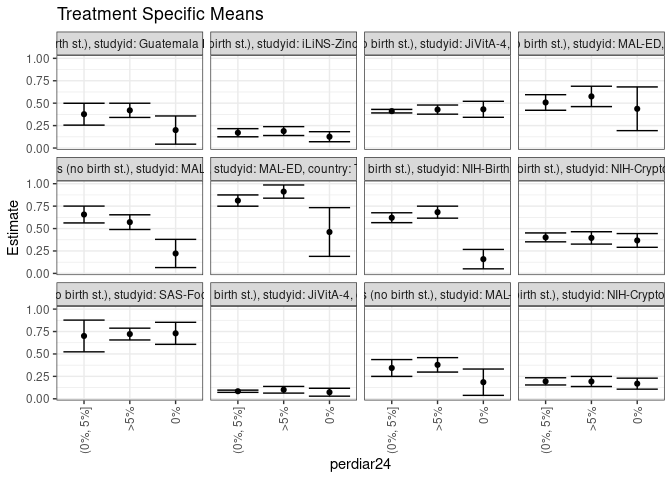

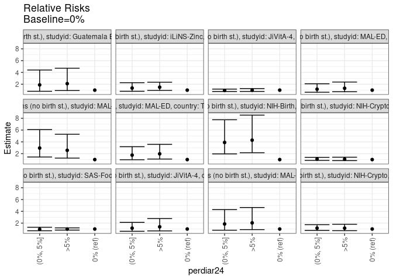

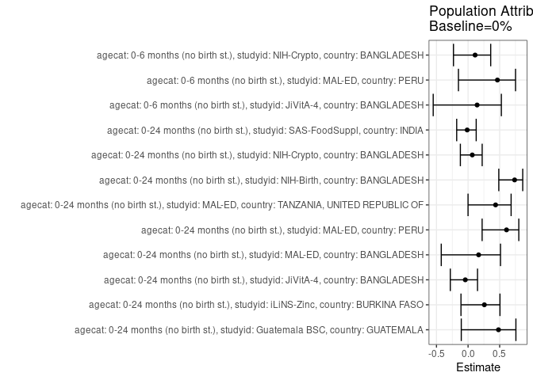

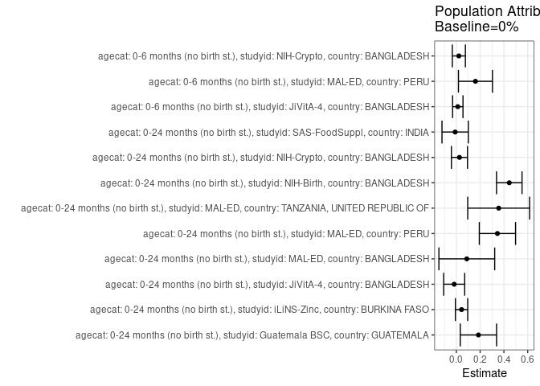

## Results Table

### Parameter: TSM

| agecat | studyid | country | intervention_level | baseline_level | estimate | ci_lower | ci_upper |
| --- | --- | --- | --- | --- | --- | --- | --- |
| 0-24 months (no birth st.) | Guatemala BSC | GUATEMALA | 0% | NA | 0.2000000 | 0.0428696 | 0.3571304 |
| 0-24 months (no birth st.) | Guatemala BSC | GUATEMALA | (0%, 5%] | NA | 0.3770492 | 0.2551696 | 0.4989288 |
| 0-24 months (no birth st.) | Guatemala BSC | GUATEMALA | >5% | NA | 0.4200000 | 0.3408478 | 0.4991522 |
| 0-24 months (no birth st.) | iLiNS-Zinc | BURKINA FASO | 0% | NA | 0.1261111 | 0.0700336 | 0.1821887 |
| 0-24 months (no birth st.) | iLiNS-Zinc | BURKINA FASO | (0%, 5%] | NA | 0.1704700 | 0.1251373 | 0.2158026 |
| 0-24 months (no birth st.) | iLiNS-Zinc | BURKINA FASO | >5% | NA | 0.1888819 | 0.1392952 | 0.2384687 |
| 0-24 months (no birth st.) | JiVitA-4 | BANGLADESH | 0% | NA | 0.4316967 | 0.3425133 | 0.5208802 |
| 0-24 months (no birth st.) | JiVitA-4 | BANGLADESH | (0%, 5%] | NA | 0.4108797 | 0.3912102 | 0.4305492 |
| 0-24 months (no birth st.) | JiVitA-4 | BANGLADESH | >5% | NA | 0.4281918 | 0.3772092 | 0.4791744 |
| 0-24 months (no birth st.) | MAL-ED | BANGLADESH | 0% | NA | 0.4375000 | 0.1938640 | 0.6811360 |
| 0-24 months (no birth st.) | MAL-ED | BANGLADESH | (0%, 5%] | NA | 0.5078125 | 0.4210038 | 0.5946212 |
| 0-24 months (no birth st.) | MAL-ED | BANGLADESH | >5% | NA | 0.5753425 | 0.4616917 | 0.6889932 |
| 0-24 months (no birth st.) | MAL-ED | PERU | 0% | NA | 0.2222222 | 0.0651116 | 0.3793329 |
| 0-24 months (no birth st.) | MAL-ED | PERU | (0%, 5%] | NA | 0.6565657 | 0.5628506 | 0.7502807 |
| 0-24 months (no birth st.) | MAL-ED | PERU | >5% | NA | 0.5714286 | 0.4892999 | 0.6535572 |
| 0-24 months (no birth st.) | MAL-ED | TANZANIA, UNITED REPUBLIC OF | 0% | NA | 0.4615385 | 0.1899249 | 0.7331521 |
| 0-24 months (no birth st.) | MAL-ED | TANZANIA, UNITED REPUBLIC OF | (0%, 5%] | NA | 0.8120805 | 0.7492119 | 0.8749492 |
| 0-24 months (no birth st.) | MAL-ED | TANZANIA, UNITED REPUBLIC OF | >5% | NA | 0.9122807 | 0.8386742 | 0.9858872 |
| 0-24 months (no birth st.) | NIH-Birth | BANGLADESH | 0% | NA | 0.1590909 | 0.0509150 | 0.2672668 |
| 0-24 months (no birth st.) | NIH-Birth | BANGLADESH | (0%, 5%] | NA | 0.6208054 | 0.5656662 | 0.6759446 |
| 0-24 months (no birth st.) | NIH-Birth | BANGLADESH | >5% | NA | 0.6827957 | 0.6158507 | 0.7497407 |
| 0-24 months (no birth st.) | NIH-Crypto | BANGLADESH | 0% | NA | 0.3674281 | 0.2908583 | 0.4439979 |
| 0-24 months (no birth st.) | NIH-Crypto | BANGLADESH | (0%, 5%] | NA | 0.4016383 | 0.3521157 | 0.4511609 |
| 0-24 months (no birth st.) | NIH-Crypto | BANGLADESH | >5% | NA | 0.3956219 | 0.3266497 | 0.4645941 |
| 0-24 months (no birth st.) | SAS-FoodSuppl | INDIA | 0% | NA | 0.7299285 | 0.6071671 | 0.8526900 |
| 0-24 months (no birth st.) | SAS-FoodSuppl | INDIA | (0%, 5%] | NA | 0.7006084 | 0.5236597 | 0.8775571 |
| 0-24 months (no birth st.) | SAS-FoodSuppl | INDIA | >5% | NA | 0.7215733 | 0.6558118 | 0.7873349 |
| 0-6 months (no birth st.) | JiVitA-4 | BANGLADESH | 0% | NA | 0.0733043 | 0.0292279 | 0.1173808 |
| 0-6 months (no birth st.) | JiVitA-4 | BANGLADESH | (0%, 5%] | NA | 0.0841312 | 0.0717332 | 0.0965293 |
| 0-6 months (no birth st.) | JiVitA-4 | BANGLADESH | >5% | NA | 0.1008978 | 0.0637479 | 0.1380477 |
| 0-6 months (no birth st.) | MAL-ED | PERU | 0% | NA | 0.1851852 | 0.0383884 | 0.3319820 |
| 0-6 months (no birth st.) | MAL-ED | PERU | (0%, 5%] | NA | 0.3434343 | 0.2497193 | 0.4371494 |
| 0-6 months (no birth st.) | MAL-ED | PERU | >5% | NA | 0.3785714 | 0.2980760 | 0.4590669 |
| 0-6 months (no birth st.) | NIH-Crypto | BANGLADESH | 0% | NA | 0.1687931 | 0.1074198 | 0.2301663 |
| 0-6 months (no birth st.) | NIH-Crypto | BANGLADESH | (0%, 5%] | NA | 0.1944056 | 0.1542335 | 0.2345777 |
| 0-6 months (no birth st.) | NIH-Crypto | BANGLADESH | >5% | NA | 0.1928686 | 0.1366177 | 0.2491194 |

### Parameter: E(Y)

| agecat | studyid | country | intervention_level | baseline_level | estimate | ci_lower | ci_upper |
| --- | --- | --- | --- | --- | --- | --- | --- |
| 0-24 months (no birth st.) | Guatemala BSC | GUATEMALA | NA | NA | 0.3855932 | 0.3233622 | 0.4478242 |
| 0-24 months (no birth st.) | iLiNS-Zinc | BURKINA FASO | NA | NA | 0.1699312 | 0.1379174 | 0.2019450 |
| 0-24 months (no birth st.) | JiVitA-4 | BANGLADESH | NA | NA | 0.4135358 | 0.3953404 | 0.4317312 |
| 0-24 months (no birth st.) | MAL-ED | BANGLADESH | NA | NA | 0.5253456 | 0.4587520 | 0.5919392 |
| 0-24 months (no birth st.) | MAL-ED | PERU | NA | NA | 0.5676692 | 0.5080232 | 0.6273151 |
| 0-24 months (no birth st.) | MAL-ED | TANZANIA, UNITED REPUBLIC OF | NA | NA | 0.8173516 | 0.7660617 | 0.8686415 |
| 0-24 months (no birth st.) | NIH-Birth | BANGLADESH | NA | NA | 0.6041667 | 0.5624147 | 0.6459187 |
| 0-24 months (no birth st.) | NIH-Crypto | BANGLADESH | NA | NA | 0.3935681 | 0.3560687 | 0.4310676 |
| 0-24 months (no birth st.) | SAS-FoodSuppl | INDIA | NA | NA | 0.7198444 | 0.6648337 | 0.7748550 |
| 0-6 months (no birth st.) | JiVitA-4 | BANGLADESH | NA | NA | 0.0855425 | 0.0741829 | 0.0969021 |
| 0-6 months (no birth st.) | MAL-ED | PERU | NA | NA | 0.3458647 | 0.2885967 | 0.4031327 |
| 0-6 months (no birth st.) | NIH-Crypto | BANGLADESH | NA | NA | 0.1898928 | 0.1597870 | 0.2199986 |

### Parameter: RR

| agecat | studyid | country | intervention_level | baseline_level | estimate | ci_lower | ci_upper |
| --- | --- | --- | --- | --- | --- | --- | --- |
| 0-24 months (no birth st.) | Guatemala BSC | GUATEMALA | 0% | 0% | 1.0000000 | 1.0000000 | 1.000000 |
| 0-24 months (no birth st.) | Guatemala BSC | GUATEMALA | (0%, 5%] | 0% | 1.8852459 | 0.8061442 | 4.408829 |
| 0-24 months (no birth st.) | Guatemala BSC | GUATEMALA | >5% | 0% | 2.1000000 | 0.9361295 | 4.710887 |
| 0-24 months (no birth st.) | iLiNS-Zinc | BURKINA FASO | 0% | 0% | 1.0000000 | 1.0000000 | 1.000000 |
| 0-24 months (no birth st.) | iLiNS-Zinc | BURKINA FASO | (0%, 5%] | 0% | 1.3517440 | 0.8080461 | 2.261272 |
| 0-24 months (no birth st.) | iLiNS-Zinc | BURKINA FASO | >5% | 0% | 1.4977419 | 0.9581482 | 2.341215 |
| 0-24 months (no birth st.) | JiVitA-4 | BANGLADESH | 0% | 0% | 1.0000000 | 1.0000000 | 1.000000 |
| 0-24 months (no birth st.) | JiVitA-4 | BANGLADESH | (0%, 5%] | 0% | 0.9517786 | 0.7684120 | 1.178902 |
| 0-24 months (no birth st.) | JiVitA-4 | BANGLADESH | >5% | 0% | 0.9918811 | 0.7797058 | 1.261794 |
| 0-24 months (no birth st.) | MAL-ED | BANGLADESH | 0% | 0% | 1.0000000 | 1.0000000 | 1.000000 |
| 0-24 months (no birth st.) | MAL-ED | BANGLADESH | (0%, 5%] | 0% | 1.1607143 | 0.6482404 | 2.078330 |
| 0-24 months (no birth st.) | MAL-ED | BANGLADESH | >5% | 0% | 1.3150685 | 0.7283377 | 2.374455 |
| 0-24 months (no birth st.) | MAL-ED | PERU | 0% | 0% | 1.0000000 | 1.0000000 | 1.000000 |
| 0-24 months (no birth st.) | MAL-ED | PERU | (0%, 5%] | 0% | 2.9545455 | 1.4363174 | 6.077583 |
| 0-24 months (no birth st.) | MAL-ED | PERU | >5% | 0% | 2.5714286 | 1.2498240 | 5.290541 |
| 0-24 months (no birth st.) | MAL-ED | TANZANIA, UNITED REPUBLIC OF | 0% | 0% | 1.0000000 | 1.0000000 | 1.000000 |
| 0-24 months (no birth st.) | MAL-ED | TANZANIA, UNITED REPUBLIC OF | (0%, 5%] | 0% | 1.7595078 | 0.9718709 | 3.185472 |
| 0-24 months (no birth st.) | MAL-ED | TANZANIA, UNITED REPUBLIC OF | >5% | 0% | 1.9766082 | 1.0913124 | 3.580075 |
| 0-24 months (no birth st.) | NIH-Birth | BANGLADESH | 0% | 0% | 1.0000000 | 1.0000000 | 1.000000 |
| 0-24 months (no birth st.) | NIH-Birth | BANGLADESH | (0%, 5%] | 0% | 3.9022052 | 1.9656098 | 7.746810 |
| 0-24 months (no birth st.) | NIH-Birth | BANGLADESH | >5% | 0% | 4.2918587 | 2.1591716 | 8.531073 |
| 0-24 months (no birth st.) | NIH-Crypto | BANGLADESH | 0% | 0% | 1.0000000 | 1.0000000 | 1.000000 |
| 0-24 months (no birth st.) | NIH-Crypto | BANGLADESH | (0%, 5%] | 0% | 1.0931072 | 0.8638608 | 1.383190 |
| 0-24 months (no birth st.) | NIH-Crypto | BANGLADESH | >5% | 0% | 1.0767328 | 0.8262477 | 1.403155 |
| 0-24 months (no birth st.) | SAS-FoodSuppl | INDIA | 0% | 0% | 1.0000000 | 1.0000000 | 1.000000 |
| 0-24 months (no birth st.) | SAS-FoodSuppl | INDIA | (0%, 5%] | 0% | 0.9598315 | 0.7086105 | 1.300117 |
| 0-24 months (no birth st.) | SAS-FoodSuppl | INDIA | >5% | 0% | 0.9885534 | 0.8178008 | 1.194958 |
| 0-6 months (no birth st.) | JiVitA-4 | BANGLADESH | 0% | 0% | 1.0000000 | 1.0000000 | 1.000000 |
| 0-6 months (no birth st.) | JiVitA-4 | BANGLADESH | (0%, 5%] | 0% | 1.1476983 | 0.6203921 | 2.123192 |
| 0-6 months (no birth st.) | JiVitA-4 | BANGLADESH | >5% | 0% | 1.3764239 | 0.6810654 | 2.781734 |
| 0-6 months (no birth st.) | MAL-ED | PERU | 0% | 0% | 1.0000000 | 1.0000000 | 1.000000 |
| 0-6 months (no birth st.) | MAL-ED | PERU | (0%, 5%] | 0% | 1.8545455 | 0.8019448 | 4.288747 |
| 0-6 months (no birth st.) | MAL-ED | PERU | >5% | 0% | 2.0442857 | 0.8997158 | 4.644916 |
| 0-6 months (no birth st.) | NIH-Crypto | BANGLADESH | 0% | 0% | 1.0000000 | 1.0000000 | 1.000000 |
| 0-6 months (no birth st.) | NIH-Crypto | BANGLADESH | (0%, 5%] | 0% | 1.1517391 | 0.7644853 | 1.735158 |
| 0-6 months (no birth st.) | NIH-Crypto | BANGLADESH | >5% | 0% | 1.1426330 | 0.7240420 | 1.803224 |

### Parameter: PAR

| agecat | studyid | country | intervention_level | baseline_level | estimate | ci_lower | ci_upper |
| --- | --- | --- | --- | --- | --- | --- | --- |
| 0-24 months (no birth st.) | Guatemala BSC | GUATEMALA | 0% | NA | 0.1855932 | 0.0328459 | 0.3383405 |
| 0-24 months (no birth st.) | iLiNS-Zinc | BURKINA FASO | 0% | NA | 0.0438200 | -0.0079441 | 0.0955842 |
| 0-24 months (no birth st.) | JiVitA-4 | BANGLADESH | 0% | NA | -0.0181609 | -0.1065200 | 0.0701981 |
| 0-24 months (no birth st.) | MAL-ED | BANGLADESH | 0% | NA | 0.0878456 | -0.1467601 | 0.3224514 |
| 0-24 months (no birth st.) | MAL-ED | PERU | 0% | NA | 0.3454470 | 0.1930317 | 0.4978622 |
| 0-24 months (no birth st.) | MAL-ED | TANZANIA, UNITED REPUBLIC OF | 0% | NA | 0.3558131 | 0.0957246 | 0.6159017 |
| 0-24 months (no birth st.) | NIH-Birth | BANGLADESH | 0% | NA | 0.4450758 | 0.3378614 | 0.5522901 |
| 0-24 months (no birth st.) | NIH-Crypto | BANGLADESH | 0% | NA | 0.0261400 | -0.0413722 | 0.0936522 |
| 0-24 months (no birth st.) | SAS-FoodSuppl | INDIA | 0% | NA | -0.0100842 | -0.1207488 | 0.1005805 |
| 0-6 months (no birth st.) | JiVitA-4 | BANGLADESH | 0% | NA | 0.0122382 | -0.0314144 | 0.0558908 |
| 0-6 months (no birth st.) | MAL-ED | PERU | 0% | NA | 0.1606795 | 0.0176611 | 0.3036979 |
| 0-6 months (no birth st.) | NIH-Crypto | BANGLADESH | 0% | NA | 0.0210997 | -0.0339151 | 0.0761146 |

### Parameter: PAF

| agecat | studyid | country | intervention_level | baseline_level | estimate | ci_lower | ci_upper |
| --- | --- | --- | --- | --- | --- | --- | --- |
| 0-24 months (no birth st.) | Guatemala BSC | GUATEMALA | 0% | NA | 0.4813187 | -0.1075266 | 0.7570891 |
| 0-24 months (no birth st.) | iLiNS-Zinc | BURKINA FASO | 0% | NA | 0.2578693 | -0.1122196 | 0.5048119 |
| 0-24 months (no birth st.) | JiVitA-4 | BANGLADESH | 0% | NA | -0.0439163 | -0.2811685 | 0.1494006 |
| 0-24 months (no birth st.) | MAL-ED | BANGLADESH | 0% | NA | 0.1672149 | -0.4244294 | 0.5131166 |
| 0-24 months (no birth st.) | MAL-ED | PERU | 0% | NA | 0.6085357 | 0.2223258 | 0.8029454 |
| 0-24 months (no birth st.) | MAL-ED | TANZANIA, UNITED REPUBLIC OF | 0% | NA | 0.4353245 | -0.0003772 | 0.6812617 |
| 0-24 months (no birth st.) | NIH-Birth | BANGLADESH | 0% | NA | 0.7366771 | 0.4861982 | 0.8650473 |
| 0-24 months (no birth st.) | NIH-Crypto | BANGLADESH | 0% | NA | 0.0664181 | -0.1218798 | 0.2231117 |
| 0-24 months (no birth st.) | SAS-FoodSuppl | INDIA | 0% | NA | -0.0140088 | -0.1800338 | 0.1286573 |
| 0-6 months (no birth st.) | JiVitA-4 | BANGLADESH | 0% | NA | 0.1430655 | -0.5518716 | 0.5268058 |
| 0-6 months (no birth st.) | MAL-ED | PERU | 0% | NA | 0.4645733 | -0.1523338 | 0.7512164 |
| 0-6 months (no birth st.) | NIH-Crypto | BANGLADESH | 0% | NA | 0.1111138 | -0.2309077 | 0.3581008 |